# DTSA-5714 Final Project Report

**Genesis Zhong**

**August 22nd, 2023**

https://github.com/genesischung/simple_web_app

## Project Description

Formula 1 is the top level racing series and the pinnacle of motorsports.

Formula 1 is more than just racing cars on the tracks, as strategy often plays out to be the decisive factor between scoring points and finishing outside the points. In each race, each driver is required to make at least one pitstop for the mandatory tire change. If one driver is able to complete the pitstop faster than the other competitors, he effectively overtakes the others without having to overtake on the track.

Currently, F1 has an official list for pitstop times, but it only measures the time for the tire change. Tire change is only a small portion of the pitstop, so this is why my product will be a nice addition.

With my web app, the users can see the pitstop time from entering the pitstop to exiting the pitstop, from the fastest to the slowest. This will be a better measurement for the time gained/lost during the pit, comparing to other drivers.

## Whiteboard Architecture

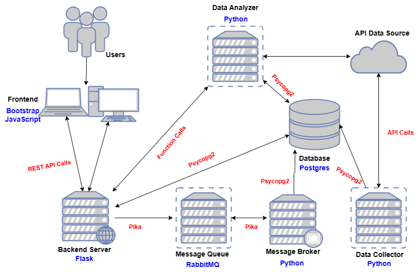

- The user uses the web app to access the service.
- The Backend Server provides the service to the front end.
- The Data Collector requests data from an API and stores the data in the database.
- The Data Analyzer performs analysis on data either from the database, or from an external API.
- The Backend Server may get data directly from the database, or calls the data analyzer to perform some analysis.
- The Backend Server can perform database operations via a Message Queue. A Message Broker will read the messages from the Message Queue and perform the database operations.

## Design Decisions for Tech Stack

### Backend Framework: Flask

This is not a difficult decision, as Python is the only common language for backend development I know. I could have picked up JavaScript on the fly, but I didn't think it would be wise to add another dimension of complexity into this project.

As I made the decision on the language, I have realistically two options: Django and Flask. Since the lecture shows an example using Flask, I gave it a try. Eventually, I just settled with it.

Looking back, Flask was quite easy to get started with, and I was able to get everything done. However, documentation for Flask is lacking when I tried to scale up my app. And this is why I would have gone with Django had I been given a second attempt. I spent a lot of time figuring out what to do with Flask, when there are lots of content on how to do the exact same task in Django.

### Frontend Framework: Bootstrap

I wasn't trying to do anything fancy, but I also want my app to look somewhat decent.

As I have absolutely zero experience in fronend development, I did some research and went with Bootstrap. Bootstrap is very easy to use on top of HTML, which makes it possible to "modernize" my web app with very little learning curve.

### Database: PostgreSQL

I originally wanted to use SQLite for a lightweight and low complexity data storage solution, given my small data needs. But during development, I realized that SQLite doesn't work with heroku's file system. In order to use a database on heroku, I had to use one of their add-ons. So I chose to use "Heroku Postgres", which is their database service based on PostgreSQL.

As I continued with the project, I realized I had made a mistake. A relational database doesn't really suit my needs, as make no use of the relationships. I would have been better off with a NoSQL database like MongoDB.

However, I only get $13 free credit per month with my GitHub student benefits on heroku. I would have to pay out of my pocket to use their MongoDB service, which is something I really want to avoid. Fortunately, Postgres supports JSON as a data type, which effectively turns it into a "partially" NoSQL database by storing unstructured data. It ended up working okay.

Had I been given another chance, I would have gone with Redis. I don't have a lot of data, so using Redis wouldn't be too expensive for the in-memory storage space. Also, I can store the information piece by piece in Redis to reduce the load of the backend server. Currently, I store data in big JSON chucks and do most of the selections in Python to reduce the load on the Postgres server. With the performance of Redis, I wouldn't have to do that.

### Code Repository: GitHub

I use Git for version control, so GitHub is my go-to option for code repository.

### Hosting: Heroku

I originally went with Render, as they still offer a free service. But the performance was severely limited and the service gets spun-off after 15 minutes of inactivity.

Heroku offers free student credit, so I won't be paying out of my pocket for a paid service. Even though it's the most basic service, it's still better than most of the free hosting services. So I gladly switched to Heroku.

### Testing Suite: PyTest and Coverage

Pytest is the go-to library for testing in a python environment. I also used Coverage to make sure most if not all my code is tested. It takes a little bit of getting used to, but it's a great learning experience.

### Continuous Integration/Continuous Deployment: GitHub Actions

I can do both continuous integration and deployment in Github Actions to avoid paying for heroku pipeline.

Also the integration with GitHub makes the CI/CD experience very smooth. I can easily look up the logs on my GitHub repository, which makes debugging a bit easier.

### Monitoring: Prometheus Flask exporter

For monitoring, I used the Prometheus Flask expoert library available on PyPi. It makes it easy to track performance metrics in a Flask-based app. It outputs metrics in a format processable by a Prometheus server.

## Home page ('/')

[figure not shown]

The home page is served as an entrance to the web app. Users can select what they want to do in the navigation bar on top. Or they can leave a message and get redirected to the messageboard.

## Message Board ('/messageboard')

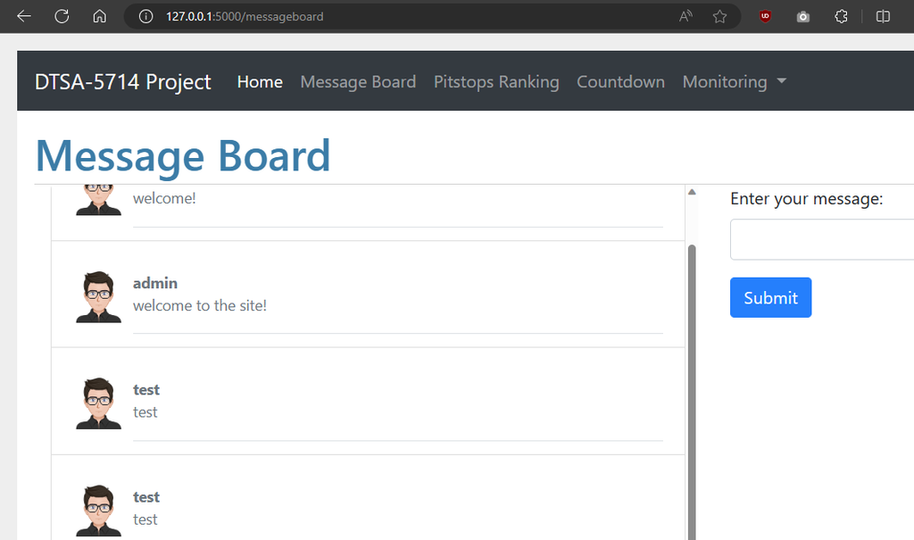

Here it displays all the messages in chronological order.

## Countdown ('/analysis/countdown')

[figure not shown]

This is a countdown to the next Formula 1 race. It gets information from the data source and do the countdown in JavaScript.

## Pitstops Ranking ('/pitstops')

[figure not shown]

This is an entrance to the Pitstops Ranking feature. Users can select the race they want to check out in the right.

### ('/analysis/pitstops/<season>/<round>')

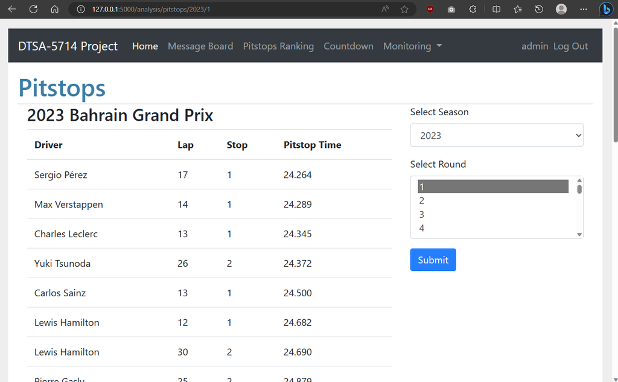

As users make the selection, they will see a list of pitstops, ranked from the fastest pitstop time to the slowest.

## Self Evaluation

### Web application basic form, reporting

I have a functional web app.

### Data Collection

Data collection is done in `app/data_collection.py`.

I have multiple functions making API calls to retrieve data from `ergast.com`, which is my data source.

### Data Analyzer

Data Analysis is done in `app/data_analysis.py`.

### Unit tests

I have some unit tests in `/tests/unit_test.py`. They mostly test the connectivity of my endpoints.

### Data persistence, any data store

I use `psycopg2` to write to my Postgres database. And the code used to initialize connection with the database is in `app/db_postgres.py`.

### Rest collaboration internal or API endpoint

I have several internal API. For example, the `/get_new_driver/\<driver_id>` internal API endpoint in `app/data_analysis.py` is meant to get a driver's information when the driver is not in the database. I don't expect any external call of this endpoint.

### Product environment

My web app is fully deployable, with the `Procfile` meant for deployment on web hosting services like Heroku.

### Integration tests

I have a bunch of integration tests in the `/tests/integration` folder.

### Using mock objects, fakes, or spys

I made some use of mock objects, below is an example in `tests/integration/test_data_collection.py`.

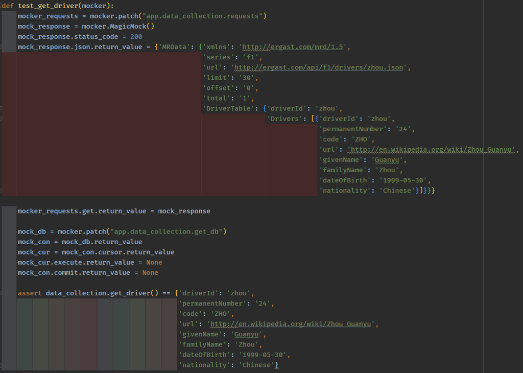

Here I use a mock object to return a pre-defined response to the API call. I also use a mock object for the `psycopg2` database connection so that it doesn't actually insert anything to my database.

### Continuous integration

Continuous Integration is done via GitHub Actions, outlined in the `.github/workflows/tests.yml` file.

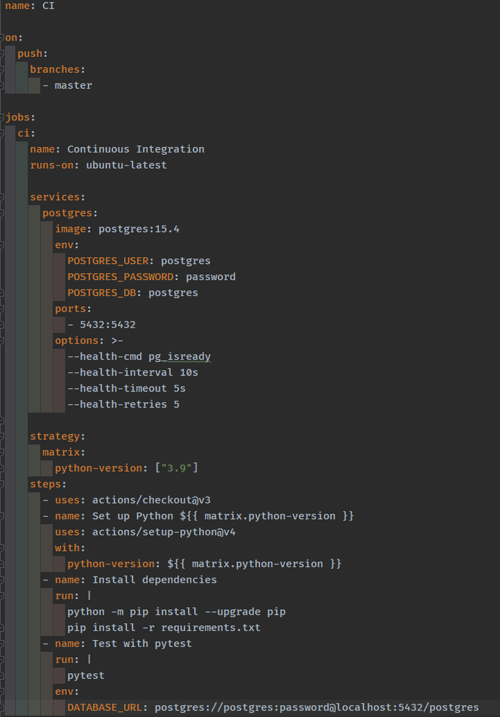

It set ups the test environment with the Python requirements and a Postgres container. Then it proceeds to run pytest.

### Production monitoring instrumenting

I use `prometheus_flask_exporter.PrometheusMetrics` for production monitoring instrumenting. Below is a code snippet from `app/f1.py`.

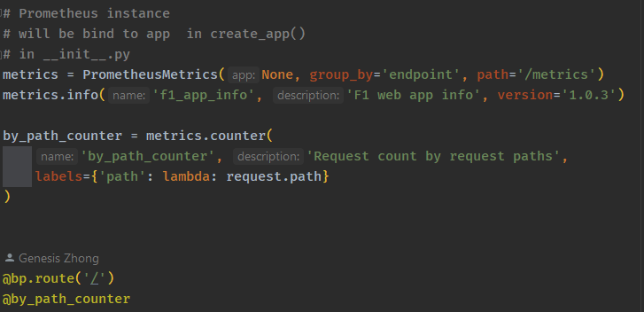

As shown above, I make a `PrometheusMetrics` instance that is bind to the `/metrics` endpoint. In addition to the built-in metrics, I also make a custom counter called `by_path_counter`. Then the this custom counter is called by using `@by_path_counter` before the function declaration.

### Event collaboration messaging

I use RabbitMQ as a message broker for inserting into the database, to help balance the load on the database. The below code segment is for the `/message` endpoint in `/app/f1.py`.

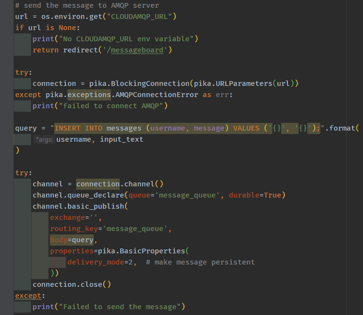

To process these messages, I have a message broker working in the background, which consumes messages from the queue and perform SQL insertion to the database. You can check out the code at `/worker/broker.py`.

### Continuous delivery

Continuous delivery is done via GitHub Actions, outlined in the `.github/workflows/deploy.yml` file.

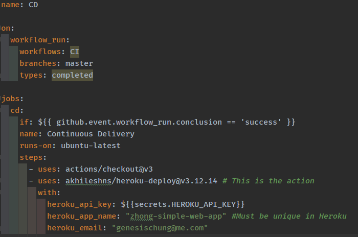

It runs as the `CI` workflow is completed, and only runs the deployment job if the `CI` workflow is `success`.

## System Requirements

The python libraries requirements are listed in `requirements.txt`.

My testing environment:

- WSL Ubuntu
- Python 3.9 and 3.10
- PostgreSQL 15.4 (docker)
- RabbitMQ 3.12 (docker)

I have deployed the app on Heroku, so you could test it out there. But in case you want to run it in your local system, here is what you have to do:

In order to deploy the message broker worker in addition to the web service on Heroku, I use the `/bin/app` which is a bash script to start worker process in the background and the web service in the foreground. Not only did it uses bash, `gunicorn` is not available in Windows. So if you want to run it in a Windows environment, you need to first run `python worker/broker.py` then `flask run`.

Also, the program requires two environment variables, `CLOUDAMQP_URL` for the RabbitMQ URL in the format of `amqp://{username}:{password}@{server}/{vhost}`, and `DATABASE_URL` in the Postgres format of `postgres://{username}:{password}@{host}:{port}/{database}`.

## Known Issues

### Driver name does not show up

When looking up older results, some driver's name may not show up. This is because the data we retrieve only contains a driver id but not the name. So I use a function to get the driver's name for driver id not currently in the database. However, when accessing older races, it will consecutively make many calls to the API, which will hit the limit of the API data site. So the calls will not be able to get the names.

The expectation is that we will rarely see new driver added to the grid. As we use the system, it will eventually load all the drivers to the database. I also added the list of the current 21 drivers to the database during initlization as a starting point.

### Database connection lost

Since the Heroku Postgres service I got is single-threaded, it is not the most stable. Occasionally, the one connection kept in Flask gets lost and the web page fails to render. Usually refreshing the page will resume the connection back to normal.

## Conclusion

This isn't what I want to do originally, as I had a more ambitious idea in mind. However, I quickly realized that this wasn't going to work, because I didn't really have the frontend skills to display the information I want to present to the users.

In addition to frontend skills, my data source also limits the possibilities of my project. What I wanted to do is possible if I clone the database of my source. They don't currently offer the information I want in a single endpoint, so I have to make a bunch of API calls to get these information. However, they limit the number of requests I can make, which prevents me from getting the data I want.

Anyhow, this is still a great learning experience for me. I have never done a "complete" software project before, and I have certainly never deployed anything to the cloud. I get a better understanding of software development, and I will definitely take on other projects in the future.